# ISYE 6402 Homework 8 Solutions

# Background

We have explored how various U.S. economic indicators are related to each other, which is a classic application for the VAR modeling. In this problem, we will study the inter-dependence and Granger causality between various economic indicators.

# Instructions on reading the data

To read the data in `R`, save the file in your working directory (make sure you have changed the directory if different from the R working directory) and read the data using the `R` function `read.csv()`

```r
# Read the monthly and quarterly data
data <- read.csv("QData.csv", head = T)
data2 <- read.csv("MData.csv", head = T)
date.quarter <- as.Date(data[, 1], "%m/%d/%Y")
date.month <- as.Date(data2[, 1], "%m/%d/%Y")
```

Here are the libraries you will need:

```r
library(data.table)
library(vars)
library(xts)
library(mgcv)
library(stats)
library(tseries)
library(aod)
```

# Question 1: Univariate Analysis

## Question 1a

Plot the time series of all indicators for comparison and discuss whether you find any similarities in terms of trend or other features. Plot also the 1st order difference plots and the corresponding ACF plots. Interpret in terms of stationarity and volatility.

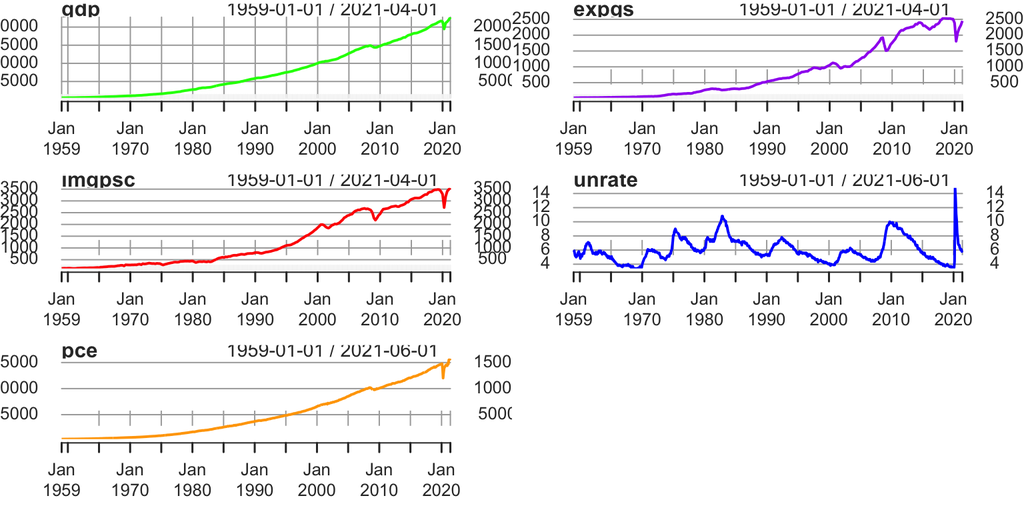

```r
# transform into time series
gdp.ts <- xts(data$GDP, date.quarter)
expgs.ts <- xts(data$EXPGS, date.quarter)
imgpgsc.ts <- xts(data$IMPGSC1, date.quarter)
unrate.ts <- xts(data2$UNRATE, date.month)
pce.ts <- xts(data2$PCE, date.month)

# merge into multivariate time series
ts.merge <- merge(gdp.ts, expgs.ts, join = 'inner')
ts.merge <- merge(ts.merge, imgpgsc.ts, join = 'inner')
ts.merge <- merge(ts.merge, unrate.ts, join = 'inner')
ts.merge <- merge(ts.merge, pce.ts, join = 'inner')
colnames(ts.merge) <- c("tsgdp", "tsexpgs", "tsimgpsc", "tsunrate", "tspce")

# Time series
par(mfrow=c(3,2))
plot(gdp.ts, xlab="time",main="gdp",type="l", col="green")
plot(expgs.ts, xlab="time",main="expgs",type="l", col="purple")
plot(imgpgsc.ts, xlab="time",main="imgpsc",type="l", col="red")
plot(unrate.ts, xlab="time",main="unrate",type="l", col="blue")
plot(pce.ts, xlab="time",main="pce",type="l", col="orange")

# 1st Order Time Series
par(mfrow=c(3,2))
```

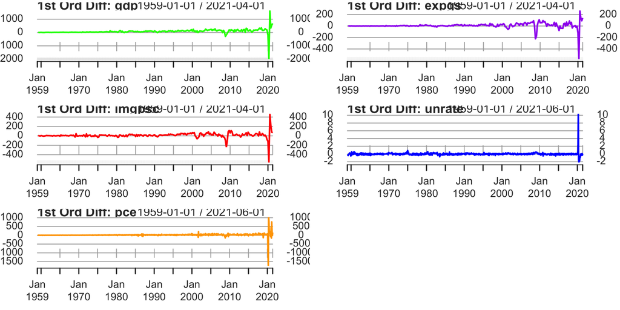

```r
plot(diff(gdp.ts), xlab="time",main="1st Ord Diff: gdp",type="l", col="green")
plot(diff(expgs.ts), xlab="time",main="1st Ord Diff: expgs",type="l", col="purple")
plot(diff(imgpgsc.ts), xlab="time",main="1st Ord Diff: imgpsc",type="l", col="red")
plot(diff(unrate.ts), xlab="time",main="1st Ord Diff: unrate",type="l", col="blue")
plot(diff(pce.ts), xlab="time",main="1st Ord Diff: pce",type="l", col="orange")

# ACF for Time series
par(mfrow=c(2,2))
```

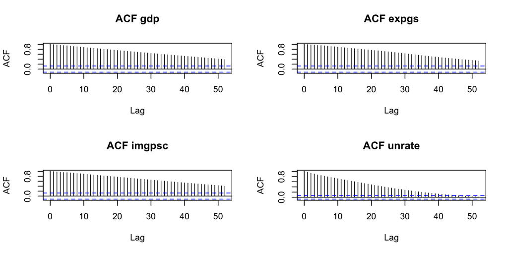

```r
acf(gdp.ts, lag.max=52,main="ACF gdp")
acf(expgs.ts,lag.max=52,main="ACF expgs")
acf(imgpgsc.ts,lag.max=52,main="ACF imgpsc")
acf(unrate.ts,lag.max=52,main="ACF unrate")
```

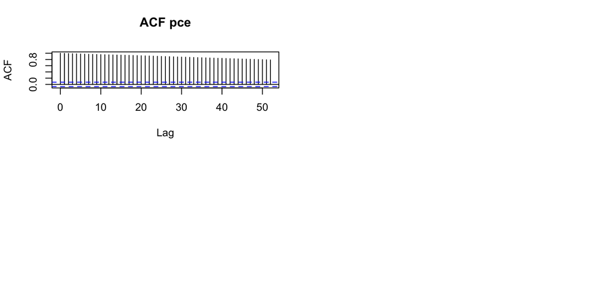

```r
acf(pce.ts, lag.max=52,main="ACF pce")

# ACF for 1st Order Time series
par(mfrow=c(2,2))
```

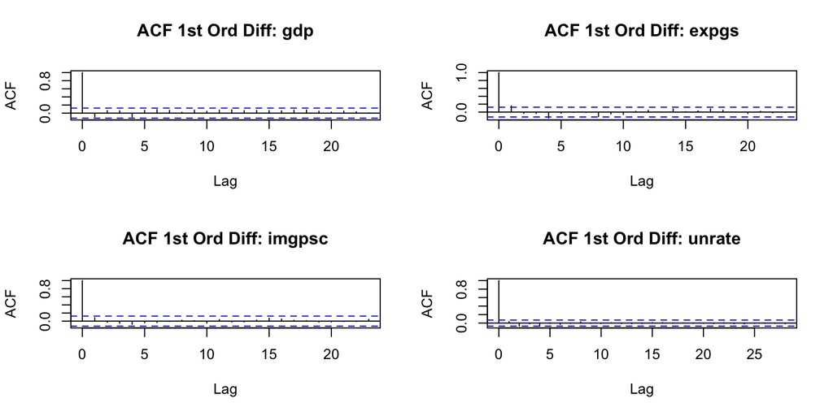

```r
acf(diff(gdp.ts), main="ACF 1st Ord Diff: gdp",na.action = na.pass)
acf(diff(expgs.ts),main="ACF 1st Ord Diff: expgs",na.action = na.pass)
acf(diff(imgpgsc.ts),main="ACF 1st Ord Diff: imgpsc",na.action = na.pass)
acf(diff(unrate.ts),main="ACF 1st Ord Diff: unrate",na.action = na.pass)
```

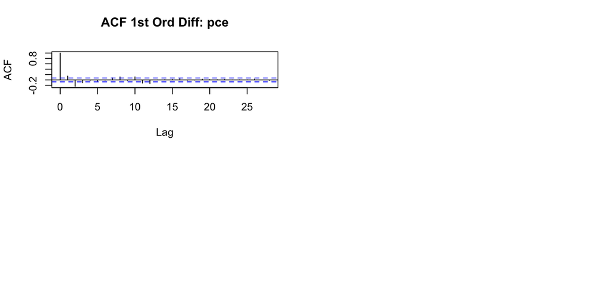

```r
acf(diff(pce.ts), main="ACF 1st Ord Diff: pce",na.action = na.pass)
```

## Question 1b

Divide the GDP data into training data including the data for years 1959 to 2020 with the last two quarters being the testing data. Fit the trend using the splines regression to the GDP training time series and apply ARMA to the residuals. Evaluate goodness of fit for the ARMA model. Forecast the first two quarters of 2021 (testing data) and compare to the observed one. Discuss why there are (or not!) significant differences between predicted vs observed.

```r
head(gdp.ts)
```

```
##               [,1]
## 1959-01-01 510.330
## 1959-04-01 522.653
## 1959-07-01 525.034
## 1959-10-01 528.600
## 1960-01-01 542.648
## 1960-04-01 541.080
```

```r
#tail(gdp.ts)
n = nrow(gdp.ts)
n
```

```
## [1] 250
```

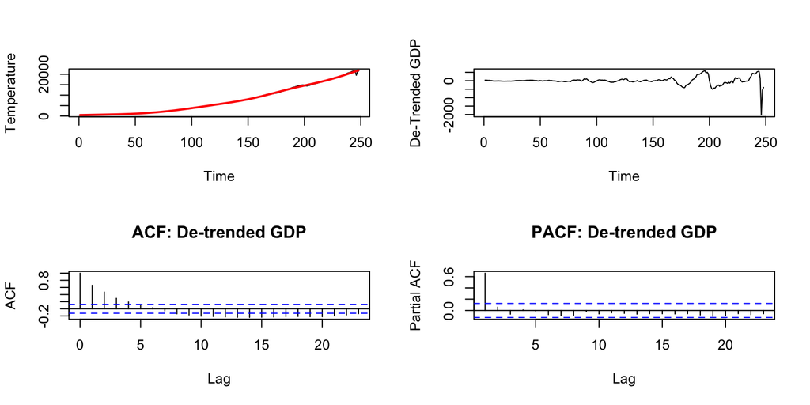

```r
gdp_train = gdp.ts[1:(n-2)]
gdp_test = gdp.ts[(n-1):n,]
#gdp_test


time.pts = c(1:length(gdp.ts))
time.pts = c(time.pts - min(time.pts))/max(time.pts)
time = time.pts[1:(n-2)]
gdp.gam.fit = gam(gdp_train~s(time))
gdp.fit.gam = ts(fitted(gdp.gam.fit))
gdp.gam.resid = ts(gdp_train - gdp.fit.gam)

par(mfrow=c(2,2))
ts.plot(gdp_train,ylab="Temperature")
lines(gdp.fit.gam,lwd=2,col="red")
plot(gdp.gam.resid,xlab="Time",ylab="De-Trended GDP",type="l")
acf(gdp.gam.resid,main="ACF: De-trended GDP")
pacf(gdp.gam.resid,main="PACF: De-trended GDP")
```

```r
## Order selection -- AIC
n_r = length(gdp.gam.resid)
n_r
```

```
## [1] 248
```

```r
norder = 6
p = c(1:norder)-1; q = c(1:norder)-1
aic = matrix(0,norder,norder)
for(i in 1:norder){
  for(j in 1:norder){
    modij = arima(gdp.gam.resid,order = c(p[i],0,q[j]), method='ML')
    aic[i,j] = modij$aic-2*(p[i]+q[j]+1)+2*(p[i]+q[j]+1)*n_r/(n_r-p[i]-q[j]-2)
  }
}

aicv = as.vector(aic)
#plot(aicv,ylab="AIC values")
indexp = rep(c(1:norder),norder)
indexq = rep(c(1:norder),each=norder)
indexaic = which(aicv == min(aicv))
porder = indexp[indexaic]-1
qorder = indexq[indexaic]-1

print(c('porder: ', porder))
```

```
## [1] "porder: " "4"
```

```r
print(c('qorder: ', qorder))
```

```
## [1] "qorder: " "3"
```

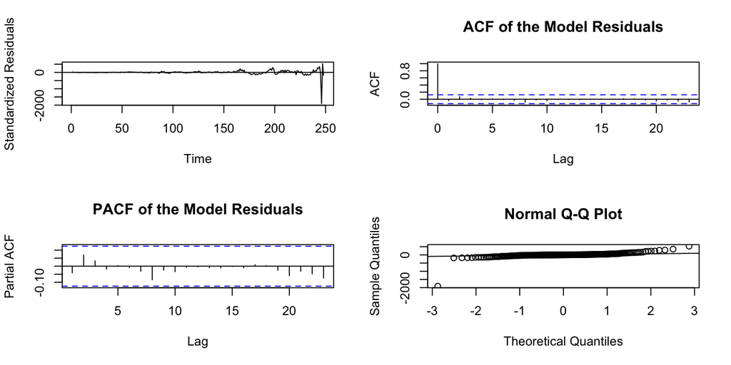

```r
## Fit ARMA Model
final_model.1 = arima(gdp.gam.resid,order = c(porder,0,qorder), method='ML')
resids.1 = resid(final_model.1)
## Residual Analysis
par (mfrow=c(2,2))
plot(resids.1, ylab='Standardized Residuals')
abline(h=0)
acf(resids.1,main= 'ACF of the Model Residuals')
pacf(resids.1,main='PACF of the Model Residuals')
qqnorm(resids.1)
qqline(resids.1)
```

```r
##### Forecasting Trend+ARMA: 4 years ahead ######

## Step 1: Predict trend
newdata = data.frame(time=time.pts[(n-1):n])
print(c('newdata',newdata))
```

```
## [[1]]
## [1] "newdata"
##
## $time
## [1] 0.992 0.996
```

```r
gam.pred= predict(gdp.gam.fit, newdata = newdata, interval=c("prediction"))
print(c('gam pred',gam.pred))
```

```
##                                     1                  2
##         "gam pred"   "22055.02513694" "22238.2911586978"
```

```r
## Step 2: Predict ARMA
ARMA.pred = predict(final_model.1,n.ahead=2)$pred
print(c('ARMA pred',ARMA.pred))
```

```
## [1] "ARMA pred"         "-321.781095911016" "-81.7683101066956"
```

```r
## Add up the predictions
final.pred.1 = ARMA.pred+gam.pred

final.pred.1
```

```
## Time Series:
## Start = 249
## End = 250
## Frequency = 1
##        1        2
## 21733.24 22156.52
```

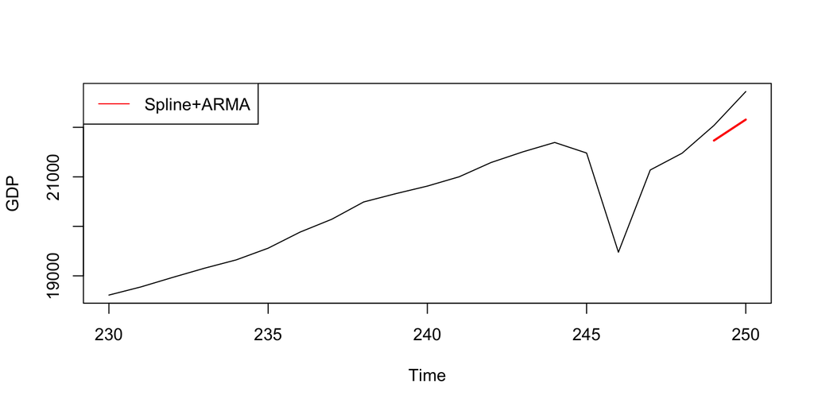

```r
par(mfrow=c(1,1))
ymin = min(c(gdp.ts[(n-20):n]),final.pred.1)
ymax = max(c(gdp.ts[(n-20):n]),final.pred.1)
t = c(1:length(gdp.ts))
plot(t[(n-20):n], gdp.ts[(n-20):n],type="l", ylim=c(ymin,ymax), xlab="Time", ylab="GDP")
lines(t[(n-1):n],final.pred.1,col="red",lwd=2)
legend('topleft',legend=c("Spline+ARMA"),col=c("red"),lty=1)
```

*Response* Goodness of Fit of ARMA was conducgted by looking at the ARMA residual plot and its ACF, PACF and qqnorm plots. ACF and PACF plots show nnon lags higher than threshold, however we see tail inn QQplot. residuals of the ARMA model shows constnt mean but increase variance toward the end. as it can be seen from the final plot that the predicted values are slightly loower than the observed ones becase as it was seen from the ARMA model and also spline model, due to very high variances in observed model toward the end of timeline, these models are not good fit for the end which consequently affects the prediction. ## Question 1c

Perform a similar analysis as in (1b) but this time applying ARIMA to the GDP time series. Compare the forecast with those in (1b) and discuss why different or similar.

```r
## Order selection -- AIC for ARIMA
norder = 6
p = c(1:norder)-1; q = c(1:norder)-1
aic = matrix(0,norder,norder)
for(i in 1:norder){
  for(j in 1:norder){
    modij = arima(gdp_train,order = c(p[i],1,q[j]), method='ML')
    aic[i,j] = modij$aic-2*(p[i]+q[j]+1)+2*(p[i]+q[j]+1)*n/(n-p[i]-q[j]-2)
  }
}

aicv = as.vector(aic)
#plot(aicv,ylab="AIC values")
indexp = rep(c(1:norder),norder)
indexq = rep(c(1:norder),each=norder)
indexaic = which(aicv == min(aicv))
porder_arima = indexp[indexaic]-1
qorder_arima = indexq[indexaic]-1

print(c('porder ARIMA: ', porder_arima))
```

```
## [1] "porder ARIMA: " "5"
```

```r
print(c('qorder ARIMA: ', qorder_arima))
```

```
## [1] "qorder ARIMA: " "4"
```

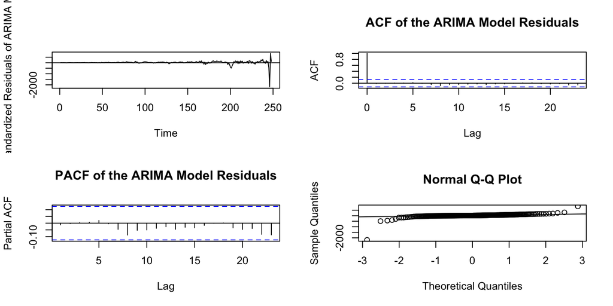

```r
## Fit ARIMA Model
final_model.2 = arima(gdp_train,order = c(porder,1,qorder), method='ML')
resids.2 = resid(final_model.2)
## Residual Analysis
par (mfrow=c(2,2))
plot(resids.2, ylab='Standardized Residuals of ARIMA Model')
abline(h=0)
acf(resids.2,main= 'ACF of the ARIMA Model Residuals')
pacf(resids.2,main='PACF of the ARIMA Model Residuals')
qqnorm(resids.2)
qqline(resids.2)
```

```r
## Step 2: Predict ARMA
ARIMA.pred = predict(final_model.2,n.ahead=2)$pred
print(c('ARIMA pred',ARIMA.pred))
```

```
## [1] "ARIMA pred"       "20690.8921097016" "21624.8264012011"
```

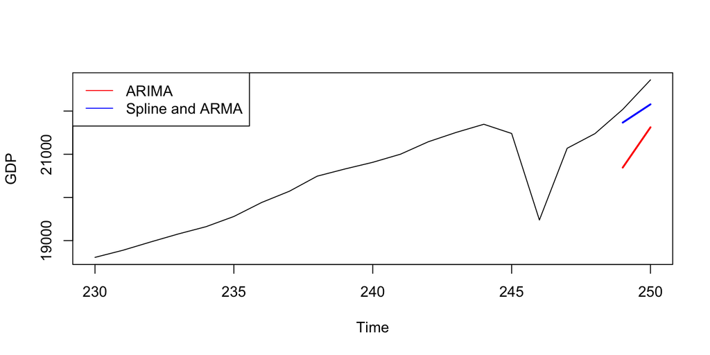

```r
par(mfrow=c(1,1))
ymin = min(c(gdp.ts[(n-20):n]),ARIMA.pred)
ymax = max(c(gdp.ts[(n-20):n]),ARIMA.pred)
t = c(1:length(gdp.ts))
plot(t[(n-20):n], gdp.ts[(n-20):n],type="l", ylim=c(ymin,ymax), xlab="Time", ylab="GDP")
lines(t[(n-1):n],ARIMA.pred ,col="red",lwd=2)
lines(t[(n-1):n],final.pred.1,col="blue",lwd=2)
legend('topleft',legend=c("ARIMA", 'Spline and ARMA'),col=c("red", 'blue'),lty=1)
```

# Question 2: Multivariate Analysis using VAR modeling

For this question, divide the data into training data (excluding the first two quarters of 2021) and testing data (including the two quarters). You will apply the modeling to the training data, and we will forecast the first two quarters of 2021.

## Question 2a

Apply the VAR model to the multivariate time series including all five economic indicators observed quarterly. (Note that you will apply VAR to the training data.) Identify the VAR order using both AIC and BIC and compare. If the selected order using AIC is larger than the selected order than selected using BIC, apply the Wald test to evaluate whether a smaller order than the one selected with AIC would be a better choice, meaning the smaller order model would perform similarly than the larger order model. Interpret the order selection.

```r
n= nrow(ts.merge)
merge_train = ts.merge[1:(n-2)]
merge_test = ts.merge[(n-1):n,]
nrow(merge_train)
```

```
## [1] 248
```

```r
nrow(merge_test)
```

```
## [1] 2
```

```r
nrow(ts.merge)
```

```
## [1] 250
```

```r
##Model Selection
VARselect(merge_train)$selection
```

```
## AIC(n)  HQ(n)  SC(n) FPE(n)
##      8      3      2      8
```

```r
## Model Fitting: Unrestricted VAR
model.var.aic=VAR(merge_train, p=8)
#summary(model.var.aic)

#coef(model.var.aic)

coef.tsgdp = coefficients(model.var.aic)$tsgdp[-(5*8+1),1]

coef.tsgdp
```

```
##    tsgdp.l1  tsexpgs.l1 tsimgpsc.l1 tsunrate.l1    tspce.l1    tsgdp.l2
##   2.1357037   0.7276059   1.7994421  52.4972391  -1.7895498  -0.6739972
##  tsexpgs.l2 tsimgpsc.l2 tsunrate.l2    tspce.l2    tsgdp.l3  tsexpgs.l3
##  -1.4747258  -1.3190287 -44.9917451   0.9270877  -0.3581480   1.4315932
## tsimgpsc.l3 tsunrate.l3    tspce.l3    tsgdp.l4  tsexpgs.l4 tsimgpsc.l4
##  -0.2399993   3.0813289   0.4604533  -0.9985907   0.5019219   0.7434690
## tsunrate.l4    tspce.l4    tsgdp.l5  tsexpgs.l5 tsimgpsc.l5 tsunrate.l5
##  -5.1634508   0.4672604   0.8163107  -2.3487237  -0.1366412  17.1078964
##    tspce.l5    tsgdp.l6  tsexpgs.l6 tsimgpsc.l6 tsunrate.l6    tspce.l6
##   0.9867721   0.3798407   0.7924507  -0.6721868 -15.1126245  -1.3539208
##    tsgdp.l7  tsexpgs.l7 tsimgpsc.l7 tsunrate.l7    tspce.l7    tsgdp.l8
##  -0.5204129   1.6707517  -0.4315491 -35.2234172   0.4356502   0.3809047
##  tsexpgs.l8 tsimgpsc.l8 tsunrate.l8    tspce.l8
##  -1.2424828   0.4600926  40.0608621  -0.4252026
```

```r
var.model = vcov(model.var.aic)[2:41,2:41]

## Granger Causality: tsexpgs
print('expgs')
```

```
## [1] "expgs"
```

```r
wald.test(b=coef.tsgdp, var.model, Terms=seq(2, 5*8, 5))
```

```
## Wald test:
## ----------
##
## Chi-squared test:
## X2 = 21.3, df = 8, P(> X2) = 0.0063
```

```r
## Granger Causality: tsimgpsc
print('imgpsc')
```

```
## [1] "imgpsc"
```

```r
wald.test(b=coef.tsgdp, var.model, Terms=seq(3, 5*8, 5))
```

```
## Wald test:
## ----------
##
## Chi-squared test:
## X2 = 52.9, df = 8, P(> X2) = 1.1e-08
```

```r
## Granger Causality: tsunrate
print('unrate')
```

```
## [1] "unrate"
```

```r
wald.test(b=coef.tsgdp, var.model, Terms=seq(4, 5*8, 5))
```

```
## Wald test:
## ----------
##
## Chi-squared test:
## X2 = 9.4, df = 8, P(> X2) = 0.31
```

```r
## Granger Causality: tspce
print('pce')
```

```
## [1] "pce"
```

```r
wald.test(b=coef.tsgdp, var.model, Terms=seq(5, 5*8, 5))
```

```
## Wald test:
## ----------
##
## Chi-squared test:
## X2 = 157.2, df = 8, P(> X2) = 0.0
```

*Response* from VAR selection method, it was found that p for AIC (8) is larger than p for BIC (2). Based on Wald test, expgs, imqpsc and pce do Granger-cause pdp since p values are less than 0.05 therefore we reject the null hypothesis that all coefficients on lagged values of these time series arer zero. However, for unrate the p value is > 0.05 so we cannot reject the null hypothesis.

## Question 2b

Based on the analysis in 2a, select the VAR order using BIC and fit that model. Print out the model summary and comment on the statistical significance of the coefficients. Apply a model selection analysis using stepwise regression to select the models for each individual time series. What do you conclude from this model selection? Apply the restrict() command in R to restrict the model of order. How do the restrcited models compare?

```r
model.var.bic=VAR(merge_train, p=2)
print('unrestricted VAR with q selected by BIC')
```

```
## [1] "unrestricted VAR with q selected by BIC"
```

```r
summary(model.var.bic)
```

```
##
## VAR Estimation Results:
## =========================
## Endogenous variables: tsgdp, tsexpgs, tsimgpsc, tsunrate, tspce
## Deterministic variables: const
## Sample size: 246
## Log Likelihood: -5143.819
## Roots of the characteristic polynomial:
## 1.008 0.971 0.971 0.7799 0.7799 0.7314 0.4271 0.4271 0.3547 0.3547
## Call:
## VAR(y = merge_train, p = 2)
##
##
## Estimation results for equation tsgdp:
## ======================================
## tsgdp = tsgdp.l1 + tsexpgs.l1 + tsimgpsc.l1 + tsunrate.l1 + tspce.l1 + tsgdp.l2 + tsexpgs.l2 + tsimgpsc.l2 + tsunrate.l2 + tspce.l2 + const
##
##              Estimate Std. Error t value Pr(>|t|)
## tsgdp.l1       2.3613     0.1811  13.037  < 2e-16 ***
## tsexpgs.l1    -0.2698     0.3395  -0.795 0.427498
## tsimgpsc.l1    1.8575     0.3188   5.827 1.85e-08 ***
## tsunrate.l1  102.3527    22.5583   4.537 9.09e-06 ***
## tspce.l1      -1.5019     0.1334 -11.255  < 2e-16 ***
## tsgdp.l2      -1.0934     0.2022  -5.408 1.57e-07 ***
## tsexpgs.l2     0.3337     0.3422   0.975 0.330443
## tsimgpsc.l2   -1.5522     0.3313  -4.686 4.72e-06 ***
## tsunrate.l2  -82.5612    23.4565  -3.520 0.000519 ***
## tspce.l2       1.0253     0.1561   6.569 3.22e-10 ***
## const       -174.0471    41.1600  -4.229 3.37e-05 ***
## ---
## Signif. codes:  0 '***' 0.001 '**' 0.01 '*' 0.05 '.' 0.1 ' ' 1
##
##
## Residual standard error: 122 on 235 degrees of freedom
## Multiple R-Squared: 0.9997,  Adjusted R-squared: 0.9996
## F-statistic: 6.859e+04 on 10 and 235 DF,  p-value: < 2.2e-16
##
##
## Estimation results for equation tsexpgs:
## ========================================
```

[output cut: 99 more lines]

```
## Covariance matrix of residuals:
##             tsgdp tsexpgs tsimgpsc tsunrate    tspce
## tsgdp    14878.79 4036.05  3626.05 -66.5328 17110.50
## tsexpgs   4036.05 1515.13  1115.80 -17.4859  4628.17
## tsimgpsc  3626.05 1115.80  1537.70 -18.6769  4471.51
## tsunrate   -66.53  -17.49   -18.68   0.4434   -90.93
## tspce    17110.50 4628.17  4471.51 -90.9341 23561.09
##
## Correlation matrix of residuals:
##            tsgdp tsexpgs tsimgpsc tsunrate   tspce
## tsgdp     1.0000  0.8501   0.7581  -0.8191  0.9139
## tsexpgs   0.8501  1.0000   0.7310  -0.6746  0.7746
## tsimgpsc  0.7581  0.7310   1.0000  -0.7152  0.7429
## tsunrate -0.8191 -0.6746  -0.7152   1.0000 -0.8896
## tspce     0.9139  0.7746   0.7429  -0.8896  1.0000
```

```r
unrate.q <- ts.merge$tsunrate
pce.q <- ts.merge$tspce


## Stepwise Regression
print('stepwise regression')
```

```
## [1] "stepwise regression"
```

```r
# tsgdp
print('for tsgdp')
```

```
## [1] "for tsgdp"
```

```r
model_tsgdp = step(lm(y ~. , data = model.var.bic$varresult$tsgdp$model), direction = 'backward', step = 5)
```

```
## Start:  AIC=2374.24
## y ~ tsgdp.l1 + tsexpgs.l1 + tsimgpsc.l1 + tsunrate.l1 + tspce.l1 +
##     tsgdp.l2 + tsexpgs.l2 + tsimgpsc.l2 + tsunrate.l2 + tspce.l2 +
##     const
##
##
## Step:  AIC=2374.24
## y ~ tsgdp.l1 + tsexpgs.l1 + tsimgpsc.l1 + tsunrate.l1 + tspce.l1 +
##     tsgdp.l2 + tsexpgs.l2 + tsimgpsc.l2 + tsunrate.l2 + tspce.l2
##
##               Df Sum of Sq     RSS    AIC
## - tsexpgs.l1   1      9400 3505915 2372.9
## - tsexpgs.l2   1     14151 3510666 2373.2
## <none>                     3496515 2374.2
## - tsunrate.l2  1    184328 3680843 2384.9
## - tsunrate.l1  1    306305 3802820 2392.9
## - tsimgpsc.l2  1    326686 3823201 2394.2
## - tsgdp.l2     1    435107 3931622 2401.1
## - tsimgpsc.l1  1    505149 4001663 2405.4
## - tspce.l2     1    642133 4138648 2413.7
## - tspce.l1     1   1884792 5381307 2478.3
## - tsgdp.l1     1   2528886 6025401 2506.1
##
## Step:  AIC=2372.9
## y ~ tsgdp.l1 + tsimgpsc.l1 + tsunrate.l1 + tspce.l1 + tsgdp.l2 +
##     tsexpgs.l2 + tsimgpsc.l2 + tsunrate.l2 + tspce.l2
##
##               Df Sum of Sq     RSS    AIC
## - tsexpgs.l2   1     13033 3518948 2371.8
## <none>                     3505915 2372.9
## - tsunrate.l2  1    180923 3686838 2383.3
## - tsunrate.l1  1    301421 3807336 2391.2
## - tsimgpsc.l2  1    324753 3830669 2392.7
## - tsgdp.l2     1    483047 3988962 2402.7
## - tsimgpsc.l1  1    516419 4022334 2404.7
## - tspce.l2     1    638646 4144562 2412.1
## - tspce.l1     1   1878055 5383970 2476.4
## - tsgdp.l1     1   2897760 6403676 2519.1
##
## Step:  AIC=2371.81
## y ~ tsgdp.l1 + tsimgpsc.l1 + tsunrate.l1 + tspce.l1 + tsgdp.l2 +
##     tsimgpsc.l2 + tsunrate.l2 + tspce.l2
##
##               Df Sum of Sq     RSS    AIC
## <none>                     3518948 2371.8
## - tsunrate.l2  1    168402 3687350 2381.3
## - tsunrate.l1  1    288402 3807350 2389.2
## - tsimgpsc.l2  1    319984 3838932 2391.2
## - tsgdp.l2     1    495671 4014619 2402.2
## - tsimgpsc.l1  1    506529 4025477 2402.9
## - tspce.l2     1    749310 4268258 2417.3
## - tspce.l1     1   1875547 5394495 2474.9
## - tsgdp.l1     1   2886549 6405497 2517.2
```

```r
#summary(model_tsgdp)
# tsexpgs
print('for tsexpgs')
```

```
## [1] "for tsexpgs"
```

```r
model_tsexpgs = step(lm(y ~. , data = model.var.bic$varresult$tsexpgs$model), direction = 'backward', step = 5)
```

```
## Start:  AIC=1812.27
## y ~ tsgdp.l1 + tsexpgs.l1 + tsimgpsc.l1 + tsunrate.l1 + tspce.l1 +
##     tsgdp.l2 + tsexpgs.l2 + tsimgpsc.l2 + tsunrate.l2 + tspce.l2 +
##     const
##
##
## Step:  AIC=1812.27
## y ~ tsgdp.l1 + tsexpgs.l1 + tsimgpsc.l1 + tsunrate.l1 + tspce.l1 +
##     tsgdp.l2 + tsexpgs.l2 + tsimgpsc.l2 + tsunrate.l2 + tspce.l2
##
##               Df Sum of Sq    RSS    AIC
## <none>                     356055 1812.3
## - tsunrate.l2  1     11337 367392 1818.0
## - tsimgpsc.l2  1     12170 368225 1818.5
## - tsexpgs.l2   1     18162 374217 1822.5
## - tsimgpsc.l1  1     19802 375857 1823.6
## - tsunrate.l1  1     22307 378362 1825.2
## - tsgdp.l2     1     31821 387876 1831.3
## - tsgdp.l1     1     50656 406711 1843.0
## - tspce.l2     1     57674 413729 1847.2
## - tspce.l1     1    118145 474200 1880.8
## - tsexpgs.l1   1    234443 590498 1934.7
```

```r
#summary(model_tsexpgs)
# tsimgpsc
print('for tsimgpsc')
```

```
## [1] "for tsimgpsc"
```

```r
model_tsimgpsc = step(lm(y ~. , data = model.var.bic$varresult$tsimgpsc$model), direction = 'backward', step = 5)
```

```
## Start:  AIC=1815.9
## y ~ tsgdp.l1 + tsexpgs.l1 + tsimgpsc.l1 + tsunrate.l1 + tspce.l1 +
##     tsgdp.l2 + tsexpgs.l2 + tsimgpsc.l2 + tsunrate.l2 + tspce.l2 +
##     const
##
##
## Step:  AIC=1815.9
## y ~ tsgdp.l1 + tsexpgs.l1 + tsimgpsc.l1 + tsunrate.l1 + tspce.l1 +
##     tsgdp.l2 + tsexpgs.l2 + tsimgpsc.l2 + tsunrate.l2 + tspce.l2
##
##               Df Sum of Sq    RSS    AIC
## - tsexpgs.l1   1       118 361477 1814.0
## - tsexpgs.l2   1       253 361612 1814.1
## <none>                     361359 1815.9
## - tsunrate.l2  1     30115 391474 1833.6
## - tsgdp.l2     1     42999 404358 1841.6
## - tsunrate.l1  1     47796 409155 1844.5
## - tsimgpsc.l2  1     57063 418422 1850.0
## - tspce.l2     1     65805 427164 1855.1
## - tsgdp.l1     1     78680 440039 1862.4
## - tspce.l1     1    165773 527132 1906.8
## - tsimgpsc.l1  1    421780 783139 2004.2
##
## Step:  AIC=1813.98
## y ~ tsgdp.l1 + tsimgpsc.l1 + tsunrate.l1 + tspce.l1 + tsgdp.l2 +
##     tsexpgs.l2 + tsimgpsc.l2 + tsunrate.l2 + tspce.l2
##
##               Df Sum of Sq    RSS    AIC
## - tsexpgs.l2   1       627 362104 1812.4
## <none>                     361477 1814.0
## - tsunrate.l2  1     30351 391827 1831.8
## - tsunrate.l1  1     48192 409669 1842.8
## - tsgdp.l2     1     57774 419251 1848.5
## - tsimgpsc.l2  1     65083 426560 1852.7
## - tspce.l2     1     70244 431721 1855.7
## - tsgdp.l1     1     97934 459410 1871.0
## - tspce.l1     1    166247 527724 1905.1
## - tsimgpsc.l1  1    477653 839130 2019.2
##
## Step:  AIC=1812.41
## y ~ tsgdp.l1 + tsimgpsc.l1 + tsunrate.l1 + tspce.l1 + tsgdp.l2 +
##     tsimgpsc.l2 + tsunrate.l2 + tspce.l2
##
##               Df Sum of Sq    RSS    AIC
## <none>                     362104 1812.4
## - tsunrate.l2  1     33856 395960 1832.4
## - tsunrate.l1  1     53018 415122 1844.0
## - tsgdp.l2     1     57233 419337 1846.5
## - tsimgpsc.l2  1     65717 427821 1851.4
## - tspce.l2     1     72231 434334 1855.2
## - tsgdp.l1     1     98768 460872 1869.7
## - tspce.l1     1    166431 528535 1903.4
## - tsimgpsc.l1  1    483646 845750 2019.1
```

```r
#summary(model_tsimgpsc)
# tsunrate
print('for tsunrate')
```

```
## [1] "for tsunrate"
```

```r
model_tsunrate = step(lm(y ~. , data = model.var.bic$varresult$tsunrate$model), direction = 'backward', step = 5)
```

```
## Start:  AIC=-189.3
## y ~ tsgdp.l1 + tsexpgs.l1 + tsimgpsc.l1 + tsunrate.l1 + tspce.l1 +
##     tsgdp.l2 + tsexpgs.l2 + tsimgpsc.l2 + tsunrate.l2 + tspce.l2 +
##     const
##
##
## Step:  AIC=-189.3
## y ~ tsgdp.l1 + tsexpgs.l1 + tsimgpsc.l1 + tsunrate.l1 + tspce.l1 +
##     tsgdp.l2 + tsexpgs.l2 + tsimgpsc.l2 + tsunrate.l2 + tspce.l2
##
##               Df Sum of Sq    RSS     AIC
## <none>                     104.21 -189.30
## - tsexpgs.l1   1     0.963 105.17 -189.04
## - tsunrate.l2  1     1.305 105.51 -188.24
## - tsexpgs.l2   1     1.546 105.75 -187.68
## - tsimgpsc.l2  1     6.119 110.33 -177.26
## - tsimgpsc.l1  1     9.466 113.67 -169.91
## - tsunrate.l1  1    12.749 116.96 -162.91
## - tspce.l2     1    15.352 119.56 -157.49
## - tsgdp.l2     1    15.562 119.77 -157.06
## - tsgdp.l1     1    26.625 130.83 -135.33
## - tspce.l1     1    42.946 147.15 -106.41
```

```r
#summary(model_tsunrate)
# tspce
print('for tspce')
```

```
## [1] "for tspce"
```

```r
model_tspce = step(lm(y ~. , data = model.var.bic$varresult$tspce$model), direction = 'backward', step = 5)
```

```
## Start:  AIC=2487.32
## y ~ tsgdp.l1 + tsexpgs.l1 + tsimgpsc.l1 + tsunrate.l1 + tspce.l1 +
##     tsgdp.l2 + tsexpgs.l2 + tsimgpsc.l2 + tsunrate.l2 + tspce.l2 +
##     const
##
##
## Step:  AIC=2487.32
## y ~ tsgdp.l1 + tsexpgs.l1 + tsimgpsc.l1 + tsunrate.l1 + tspce.l1 +
##     tsgdp.l2 + tsexpgs.l2 + tsimgpsc.l2 + tsunrate.l2 + tspce.l2
##
##               Df Sum of Sq     RSS    AIC
## - tsexpgs.l1   1      3782 5540639 2485.5
## - tsexpgs.l2   1     11004 5547861 2485.8
## <none>                     5536857 2487.3
## - tsimgpsc.l2  1    155199 5692056 2492.1
## - tsimgpsc.l1  1    314354 5851211 2498.9
## - tsunrate.l2  1    392136 5928993 2502.2
## - tsunrate.l1  1    604824 6141681 2510.8
## - tspce.l1     1    638986 6175843 2512.2
## - tsgdp.l2     1    870655 6407512 2521.2
## - tspce.l2     1    896623 6433480 2522.2
## - tsgdp.l1     1   1662805 7199662 2549.9
##
## Step:  AIC=2485.48
## y ~ tsgdp.l1 + tsimgpsc.l1 + tsunrate.l1 + tspce.l1 + tsgdp.l2 +
##     tsexpgs.l2 + tsimgpsc.l2 + tsunrate.l2 + tspce.l2
##
##               Df Sum of Sq     RSS    AIC
## - tsexpgs.l2   1     44633 5585272 2485.5
## <none>                     5540639 2485.5
## - tsimgpsc.l2  1    155664 5696303 2490.3
## - tsimgpsc.l1  1    327283 5867922 2497.6
## - tsunrate.l2  1    389438 5930077 2500.2
## - tsunrate.l1  1    601425 6142064 2508.8
## - tspce.l1     1    636436 6177075 2510.2
## - tspce.l2     1    913924 6454564 2521.0
## - tsgdp.l2     1   1046923 6587563 2526.1
## - tsgdp.l1     1   1926849 7467489 2556.9
##
## Step:  AIC=2485.46
## y ~ tsgdp.l1 + tsimgpsc.l1 + tsunrate.l1 + tspce.l1 + tsgdp.l2 +
##     tsimgpsc.l2 + tsunrate.l2 + tspce.l2
##
##               Df Sum of Sq     RSS    AIC
## <none>                     5585272 2485.5
## - tsimgpsc.l2  1    149163 5734435 2489.9
## - tsimgpsc.l1  1    310012 5895284 2496.8
## - tsunrate.l2  1    350892 5936165 2498.4
## - tsunrate.l1  1    558909 6144181 2506.9
## - tspce.l1     1    633638 6218910 2509.9
## - tsgdp.l2     1   1080189 6665461 2526.9
## - tspce.l2     1   1117826 6703098 2528.3
## - tsgdp.l1     1   1905649 7490921 2555.7
```

```r
#summary(model_tspce)



## Model Fitting: Restricted VAR
model.var.bic.restrict=restrict(model.var.bic)
print('restricted VAR.bic')
```

```
## [1] "restricted VAR.bic"
```

```r
summary(model.var.bic.restrict)
```

```
##
## VAR Estimation Results:
## =========================
## Endogenous variables: tsgdp, tsexpgs, tsimgpsc, tsunrate, tspce
## Deterministic variables: const
## Sample size: 246
## Log Likelihood: -5159.564
## Roots of the characteristic polynomial:
## 1.007 0.9674 0.9493 0.8832 0.7887 0.5335 0.5335 0.4007 0.4007 0.3983
## Call:
## VAR(y = merge_train, p = 2)
##
##
## Estimation results for equation tsgdp:
## ======================================
## tsgdp = tsgdp.l1 + tsimgpsc.l1 + tsunrate.l1 + tspce.l1 + tsgdp.l2 + tsimgpsc.l2 + tsunrate.l2 + tspce.l2 + const
##
##              Estimate Std. Error t value Pr(>|t|)
## tsgdp.l1       2.2954     0.1646  13.943  < 2e-16 ***
## tsimgpsc.l1    1.7516     0.2999   5.841 1.70e-08 ***
## tsunrate.l1   96.8640    21.9784   4.407 1.59e-05 ***
## tspce.l1      -1.4974     0.1332 -11.239  < 2e-16 ***
## tsgdp.l2      -1.0292     0.1781  -5.778 2.37e-08 ***
## tsimgpsc.l2   -1.4576     0.3140  -4.642 5.71e-06 ***
## tsunrate.l2  -76.9622    22.8527  -3.368 0.000884 ***
## tspce.l2       1.0386     0.1462   7.104 1.41e-11 ***
## const       -178.7246    40.9369  -4.366 1.89e-05 ***
## ---
## Signif. codes:  0 '***' 0.001 '**' 0.01 '*' 0.05 '.' 0.1 ' ' 1
##
##
## Residual standard error: 121.9 on 237 degrees of freedom
## Multiple R-Squared: 0.9999,  Adjusted R-squared: 0.9999
## F-statistic: 1.833e+05 on 9 and 237 DF,  p-value: < 2.2e-16
##
##
## Estimation results for equation tsexpgs:
## ========================================
## tsexpgs = tsgdp.l1 + tsexpgs.l1 + tsimgpsc.l1 + tsunrate.l1 + tspce.l1 + tsgdp.l2 + tsexpgs.l2 + tsimgpsc.l2 + tsunrate.l2 + tspce.l2 + const
##
```

[output cut: 90 more lines]

```
## Covariance matrix of residuals:
##             tsgdp tsexpgs tsimgpsc tsunrate   tspce
## tsgdp    14974.25 4036.05  3609.40 -67.5888 17238.5
## tsexpgs   4036.05 1515.13  1115.80 -17.4859  4628.2
## tsimgpsc  3609.40 1115.80  1540.87 -18.4888  4446.2
## tsunrate   -67.59  -17.49   -18.49   0.4581   -92.4
## tspce    17238.50 4628.17  4446.15 -92.3960 23767.1
##
## Correlation matrix of residuals:
##            tsgdp tsexpgs tsimgpsc tsunrate   tspce
## tsgdp     1.0000  0.8473   0.7514  -0.8161  0.9138
## tsexpgs   0.8473  1.0000   0.7303  -0.6637  0.7713
## tsimgpsc  0.7514  0.7303   1.0000  -0.6959  0.7347
## tsunrate -0.8161 -0.6637  -0.6959   1.0000 -0.8855
## tspce     0.9138  0.7713   0.7347  -0.8855  1.0000
```

*Response* Based on VAR model using p=2 (from BIC) (model.var.bic), the following constants for the folllowing varibales were NOT statistically significant in 95% confidence interval since their p values are greater than 0.05. equation for tsgdp: tsexpgs.l1, tsexpgs.l2 equation for tsimgpsc: tsexpgs.l1, tsexpgs.l2 equation for tsunrate: tsexpgs.l1, tsexpgs.l2, tsunrate.l2 equation for tspcs: tsexpgs.l1, tsexpgs.l2

Backward stepwise regression rsults are below: for gdp y ~ tsgdp.l1 + tsimgpsc.l1 + tsunrate.l1 + tspce.l1 + tsgdp.l2 + tsimgpsc.l2 + tsunrate.l2 + tspce.l2

for tsexpgs y ~ tsgdp.l1 + tsexpgs.l1 + tsimgpsc.l1 + tsunrate.l1 + tspce.l1 + tsgdp.l2 + tsexpgs.l2 + tsimgpsc.l2 + tsunrate.l2 + tspce.l2

for tsimgpsc y ~ tsgdp.l1 + tsimgpsc.l1 + tsunrate.l1 + tspce.l1 + tsgdp.l2 + tsimgpsc.l2 + tsunrate.l2 + tspce.l2

for tsunrate y ~ tsgdp.l1 + tsexpgs.l1 + tsimgpsc.l1 + tsunrate.l1 + tspce.l1 + tsgdp.l2 + tsexpgs.l2 + tsimgpsc.l2 + tsunrate.l2 + tspce.l2

for tspce y ~ tsgdp.l1 + tsimgpsc.l1 + tsunrate.l1 + tspce.l1 + tsgdp.l2 + tsimgpsc.l2 + tsunrate.l2 + tspce.l2

Stepwise regression produced the same reuslts of restricted VAR except for unrate. Stepwise regression did not eliminate any paramteres for this one.

The restricted VAR model with p = 2 (based on BIC), shows that all coefficients that were identified to be statistically insignificant in 95% conficende interval in first model (model.var.bic) are removed from the equations; therefore all the coeffiicents in the model.var.bic.restricted are statistically significant in 95% confidence interval.

## Question 2c

Evaluate the goodness of fit using the multivariate ARCH test, the Jarque-Bera test and the Portmanteau test. State which assumptions are satisfied, and which are violated. (Note: While we evaluate the residuals for the normality assumption, we do not necessarily assume normality of the data. We use the normality assumption if we use the t-test to evaluate statistical significance.)

```r
## Residual Analysis: Constant Variance Assumption
arch.test(model.var.bic.restrict)
```

```
##
##  ARCH (multivariate)
##
## data:  Residuals of VAR object model.var.bic.restrict
## Chi-squared = 2467, df = 1125, p-value < 2.2e-16
```

```r
## Residual Analysis: Normality Assumption (Jarque Bera test)
normality.test(model.var.bic.restrict)
```

```
## $JB
##
##  JB-Test (multivariate)
##
## data:  Residuals of VAR object model.var.bic.restrict
## Chi-squared = 22552, df = 10, p-value < 2.2e-16
##
##
## $Skewness
##
##  Skewness only (multivariate)
##
## data:  Residuals of VAR object model.var.bic.restrict
## Chi-squared = 770.65, df = 5, p-value < 2.2e-16
##
##
## $Kurtosis
##
##  Kurtosis only (multivariate)
##
## data:  Residuals of VAR object model.var.bic.restrict
## Chi-squared = 21782, df = 5, p-value < 2.2e-16
```

```r
## Root analysis: is this VAR process stable?
roots_mod = roots(model.var.bic.restrict)
r =sum(roots_mod>=1)
r
```

```
## [1] 1
```

```r
## Residual Analysis: Uncorrelated Errors Assumption (Portmanteau test)
#serialtest = serial.test(model.var.bic.restrict)
#serialtest
#plot(serialtest)
```

*Response* Based on the arch test, as p value is close to zero, we reject the null hypothesis of constant variance. Based on J-B test, as p value close to zero, we reject he null hypothesis of normality. We have one root equal or larger than 1 indicatinng that this VAR is not stable. ## Question 2d

Using the VAR model with the order selected using BIC, forecast the first two quarters of 2021 using the unrestricted and restricted VAR. Include 95% confidence intervals. Compare the predictions to the observed data. (You don’t need to plot them (but can if you’d like). Using mean absolute percentage error and the precision measure, compare the predictions for GDP derived from the univariate analysis (Question 1) and this multivariate analysis. Discuss on the differences or similarities.

```r
#for unrestricted  VAR
pred.test.unrestricted.bic <- predict(model.var.bic,n.ahead=2)
print('unrestricted VAR -bic')
```

```
## [1] "unrestricted VAR -bic"
```

```r
pred.test.unrestricted.bic
```

```
## $tsgdp
##          fcst    lower    upper       CI
## [1,] 21417.96 21178.89 21657.04 239.0737
## [2,] 21946.02 21586.24 22305.80 359.7781
##
## $tsexpgs
##          fcst    lower    upper        CI
## [1,] 2228.680 2152.389 2304.971  76.29088
## [2,] 2357.263 2230.386 2484.140 126.87675
##
## $tsimgpsc
##          fcst    lower    upper        CI
## [1,] 3410.416 3333.559 3487.273  76.85703
## [2,] 3562.431 3431.152 3693.710 131.27856
##
## $tsunrate
##          fcst    lower    upper       CI
## [1,] 7.790558 6.485396 9.095720 1.305162
## [2,] 6.639000 4.892212 8.385789 1.746789
##
## $tspce
##          fcst    lower    upper       CI
## [1,] 14176.80 13875.95 14477.65 300.8471
## [2,] 14689.66 14309.44 15069.87 380.2169
```

```r
print('Observed data')
```

```
## [1] "Observed data"
```

```r
merge_test
```

```
##               tsgdp  tsexpgs tsimgpsc tsunrate   tspce
## 2021-01-01 22038.23 2311.930 3488.445      6.3 14857.9
## 2021-04-01 22722.58 2452.868 3554.691      6.1 15630.0
```

```r
### Mean Absolute Percentage Error (MAPE)
# for gdp
pred_gdp = pred.test.unrestricted.bic[[1]]$tsgdp[,1]
oobs_gdp = merge_test$tsgdp

print('MAPE for unrestricted VAR')
```

```
## [1] "MAPE for unrestricted VAR"
```

```r
mean(abs(pred_gdp-oobs_gdp)/oobs_gdp)
```

```
## [1] 0.03116033
```

```r
### Precision Measure (PM)
print('PM for unrestricted VAR')
```

```
## [1] "PM for unrestricted VAR"
```

```r
sum((pred_gdp-oobs_gdp)^2)/sum((oobs_gdp-mean(oobs_gdp))^2)
```

```
## [1] 4.218177
```

```r
#for restricted  VAR
pred.test.restricted.bic <- as.vector(predict(model.var.bic.restrict,n.ahead=2))
print('restricted VAR -bic')
```

```
## [1] "restricted VAR -bic"
```

```r
pred.test.restricted.bic
```

```
## $tsgdp
##          fcst    lower    upper       CI
## [1,] 21471.75 21232.92 21710.57 238.8253
## [2,] 21872.65 21513.51 22231.79 359.1417
##
## $tsexpgs
##         fcst    lower    upper        CI
## [1,] 2228.68 2152.389 2304.971  76.29088
## [2,] 2314.38 2187.012 2441.749 127.36843
##
## $tsimgpsc
##          fcst    lower    upper       CI
## [1,] 3400.007 3323.396 3476.618  76.6109
## [2,] 3484.708 3352.164 3617.251 132.5433
##
## $tsunrate
##          fcst    lower    upper       CI
## [1,] 6.866686 5.548510 8.184862 1.318176
## [2,] 5.663752 3.881227 7.446276 1.782525
##
## $tspce
##          fcst    lower    upper       CI
## [1,] 14260.60 13959.72 14561.48 300.8819
## [2,] 14634.36 14254.79 15013.93 379.5673
```

```r
### Mean Absolute Percentage Error (MAPE)
# for gdp
pred_gdp2 = pred.test.restricted.bic[[1]]$tsgdp[,1]

print('MAPE for restricted VAR')
```

```
## [1] "MAPE for restricted VAR"
```

```r
mean(abs(pred_gdp2-oobs_gdp)/oobs_gdp)
```

```
## [1] 0.03155454
```

```r
### Precision Measure (PM)
print('PM for restricted VAR')
```

```
## [1] "PM for restricted VAR"
```

```r
sum((pred_gdp2-oobs_gdp)^2)/sum((oobs_gdp-mean(oobs_gdp))^2)
```

```
## [1] 4.455214
```

```r
#for ARMA (from Q1)
### Mean Absolute Percentage Error (MAPE)
print('MAPE for ARIMA')
```

```
## [1] "MAPE for ARIMA"
```

```r
mean(abs(as.vector(ARIMA.pred)-oobs_gdp)/oobs_gdp)
```

```
## [1] 0.0547237
```

```r
### Precision Measure (PM)
print('PM for ARIMA')
```

```
## [1] "PM for ARIMA"
```

```r
sum((as.vector(ARIMA.pred)-oobs_gdp)^2)/sum((oobs_gdp-mean(oobs_gdp))^2)
```

```
## [1] 12.89816
```

```r
#for TREND+ARMA (from Q1)
### Mean Absolute Percentage Error (MAPE)
print('MAPE for TREND+ARMA')
```

```
## [1] "MAPE for TREND+ARMA"
```

```r
mean(abs(as.vector(final.pred.1)-oobs_gdp)/oobs_gdp)
```

```
## [1] 0.01937524
```

```r
### Precision Measure (PM)
print('PM for TREND+ARMA')
```

```
## [1] "PM for TREND+ARMA"
```

```r
sum((as.vector(final.pred.1)-oobs_gdp)^2)/sum((oobs_gdp-mean(oobs_gdp))^2)
```

```
## [1] 1.76553
```

In general, predictions from both models are not that good. MAPE and PM for unrestricted VAR is very sllightly lower than those of restricted VAR. However, it is really difficult to say one is better than the other based on MAPE or PM since these values are too close to each other. coomparing to the univariate models, VAR model did much better compared to ARIMA as PM and MAPE values of VAR are lower than those for ARIMA. HOwever, trend + ARMA model perfromed better than VAR ad its MAPE and PM values are much lower than those of VAR model.

## Question 2e

Perform a Granger Causality analysis using Wald test to evaluate whether any of the economic indicators lead GDP. Would any of the indicators help in predicting or explaining GDP for next quarters? Provide your interpretation based on the Granger causality as well as for forecasting comparison in (2d).

```r
coef.tsgdp.r = coef(model.var.bic.restrict)$tsgdp[-(4*2+1),1]
coef.tsgdp.r
```

```
##    tsgdp.l1 tsimgpsc.l1 tsunrate.l1    tspce.l1    tsgdp.l2 tsimgpsc.l2
##    2.295362    1.751647   96.864046   -1.497351   -1.029211   -1.457642
## tsunrate.l2    tspce.l2
##  -76.962222    1.038608
```

```r
var.model.r = vcov(model.var.bic.restrict)[2:11,2:11]
var.m.r = var.model.r[-2,-2]
var.m.r = var.m.r[-6,-6]
var.m.r
```

```
##                   tsgdp:tsgdp.l1 tsgdp:tsimgpsc.l1 tsgdp:tsunrate.l1
## tsgdp:tsgdp.l1        0.03280591     -0.0115709615         0.4425386
## tsgdp:tsimgpsc.l1    -0.01157096      0.1016269084         1.3014773
## tsgdp:tsunrate.l1     0.44253859      1.3014772504       508.8762338
## tsgdp:tspce.l1       -0.01540614     -0.0001676602         1.2863816
## tsgdp:tsgdp.l2       -0.03469934      0.0078000085        -0.7103385
## tsgdp:tsimgpsc.l2     0.01045628     -0.1023851936        -1.3046580
## tsgdp:tsunrate.l2    -0.48995488     -1.5298627558      -514.0668551
## tsgdp:tspce.l2        0.01823365      0.0056920980        -0.9742392
##                   tsgdp:tspce.l1 tsgdp:tsgdp.l2 tsgdp:tsimgpsc.l2
## tsgdp:tsgdp.l1     -0.0154061394   -0.034699343      0.0104562760
## tsgdp:tsimgpsc.l1  -0.0001676602    0.007800008     -0.1023851936
## tsgdp:tsunrate.l1   1.2863816395   -0.710338494     -1.3046580076
## tsgdp:tspce.l1      0.0178070661    0.013598164     -0.0004554729
## tsgdp:tsgdp.l2      0.0135981644    0.040882389     -0.0044103068
## tsgdp:tsimgpsc.l2  -0.0004554729   -0.004410307      0.1097269257
## tsgdp:tsunrate.l2  -1.3002655015    0.810174927      1.7493623017
## tsgdp:tspce.l2     -0.0149648237   -0.023518243     -0.0101756053
##                   tsgdp:tsunrate.l2 tsgdp:tspce.l2
## tsgdp:tsgdp.l1           -0.4899549    0.018233646
## tsgdp:tsimgpsc.l1        -1.5298628    0.005692098
## tsgdp:tsunrate.l1      -514.0668551   -0.974239204
## tsgdp:tspce.l1           -1.3002655   -0.014964824
## tsgdp:tsgdp.l2            0.8101749   -0.023518243
## tsgdp:tsimgpsc.l2         1.7493623   -0.010175605
## tsgdp:tsunrate.l2       550.2095905    0.861793217
## tsgdp:tspce.l2            0.8617932    0.024360236
```

```r
## Granger Causality: tsimgpsc
print('imgpsc')
```

```
## [1] "imgpsc"
```

```r
wald.test(b=coef.tsgdp.r, var.m.r, Terms=seq(2, 4*2, 4))
```

```
## Wald test:
## ----------
##
## Chi-squared test:
## X2 = 44.5, df = 2, P(> X2) = 2.1e-10
```

```r
## Granger Causality: tsunrate
print('unrate')
```

```
## [1] "unrate"
```

```r
wald.test(b=coef.tsgdp.r, var.m.r, Terms=seq(3, 4*2, 4))
```

```
## Wald test:
## ----------
##
## Chi-squared test:
## X2 = 32.6, df = 2, P(> X2) = 8.5e-08
```

```r
## Granger Causality: tspce
print('pce')
```

```
## [1] "pce"
```

```r
wald.test(b=coef.tsgdp.r, var.m.r, Terms=seq(4, 4*2, 4))
```

```
## Wald test:
## ----------
##
## Chi-squared test:
## X2 = 130.0, df = 2, P(> X2) = 0.0
```

*Response* All p values from Wald are very close to zero so we reject the null hypothesis that all coefficients on lagged values of these time series are zero.

# Question 3

For this question, consider the training data to include the time values up to December 2018 and the testing data to include the first two quarters of 2019.

## Question 3a

Apply the VAR modeling approach with the order selected using the BIC approach giving the unrestricted VAR model. Apply a model selection analysis using stepwise regression to select the models for each individual time series. Based on the selected models, form the restricted VAR model. Compare these two models in terms of coefficients and their statistical significance with the models derived in Question 2.

```r
n= nrow(ts.merge)
#n
new_train =  ts.merge[1:(n-10)]
new_test = ts.merge[(n-9):(n-8),]
#tail(new_train)
#nrow(new_train)
#new_test


##Model Selection
VARselect(new_train)$selection
```

```
## AIC(n)  HQ(n)  SC(n) FPE(n)
##      5      2      2      5
```

```r
## Model Fitting: Unrestricted VAR based on BIC
print('unrestricted VAR.new')
```

```
## [1] "unrestricted VAR.new"
```

```r
model.var.new=VAR(new_train, p=2)
summary(model.var.new)
```

```
##
## VAR Estimation Results:
## =========================
## Endogenous variables: tsgdp, tsexpgs, tsimgpsc, tsunrate, tspce
## Deterministic variables: const
## Sample size: 238
## Log Likelihood: -4489.771
## Roots of the characteristic polynomial:
## 1.008 0.9767 0.9767 0.9444 0.8047 0.8047 0.3497 0.3497 0.2079 0.02358
## Call:
## VAR(y = new_train, p = 2)
##
##
## Estimation results for equation tsgdp:
## ======================================
## tsgdp = tsgdp.l1 + tsexpgs.l1 + tsimgpsc.l1 + tsunrate.l1 + tspce.l1 + tsgdp.l2 + tsexpgs.l2 + tsimgpsc.l2 + tsunrate.l2 + tspce.l2 + const
##
##              Estimate Std. Error t value Pr(>|t|)
## tsgdp.l1      1.20605    0.08567  14.077  < 2e-16 ***
## tsexpgs.l1   -0.06457    0.15969  -0.404   0.6863
## tsimgpsc.l1   0.60903    0.14510   4.197 3.88e-05 ***
## tsunrate.l1 -13.81026   10.74494  -1.285   0.2000
## tspce.l1      0.03440    0.13134   0.262   0.7936
## tsgdp.l2     -0.17178    0.09376  -1.832   0.0682 .
## tsexpgs.l2   -0.01950    0.15990  -0.122   0.9030
## tsimgpsc.l2  -0.61316    0.14612  -4.196 3.89e-05 ***
## tsunrate.l2  16.82789   10.78852   1.560   0.1202
## tspce.l2     -0.05983    0.11824  -0.506   0.6134
## const       -14.43647   19.16348  -0.753   0.4520
## ---
## Signif. codes:  0 '***' 0.001 '**' 0.01 '*' 0.05 '.' 0.1 ' ' 1
##
##
## Residual standard error: 51 on 227 degrees of freedom
## Multiple R-Squared: 0.9999,  Adjusted R-squared: 0.9999
## F-statistic: 3.343e+05 on 10 and 227 DF,  p-value: < 2.2e-16
##
##
## Estimation results for equation tsexpgs:
## ========================================
```

[output cut: 99 more lines]

```
## Covariance matrix of residuals:
##             tsgdp  tsexpgs tsimgpsc tsunrate   tspce
## tsgdp    2601.337 834.1216   408.80 -2.02513 962.396
## tsexpgs   834.122 630.2867   241.46 -0.55487 365.585
## tsimgpsc  408.800 241.4583   570.31 -1.47026 239.100
## tsunrate   -2.025  -0.5549    -1.47  0.08383  -0.793
## tspce     962.396 365.5850   239.10 -0.79302 974.859
##
## Correlation matrix of residuals:
##            tsgdp  tsexpgs tsimgpsc tsunrate    tspce
## tsgdp     1.0000  0.65142   0.3356 -0.13714  0.60434
## tsexpgs   0.6514  1.00000   0.4027 -0.07634  0.46639
## tsimgpsc  0.3356  0.40273   1.0000 -0.21264  0.32067
## tsunrate -0.1371 -0.07634  -0.2126  1.00000 -0.08773
## tspce     0.6043  0.46639   0.3207 -0.08773  1.00000
```

```r
## Stepwise Regression
print('stepwise regression')
```

```
## [1] "stepwise regression"
```

```r
# tsgdp
print('for tsgdp')
```

```
## [1] "for tsgdp"
```

```r
model_tsgdp = step(lm(y ~. , data = model.var.new$varresult$tsgdp$model), direction = 'backward', step = 8)
```

```
## Start:  AIC=1882.32
## y ~ tsgdp.l1 + tsexpgs.l1 + tsimgpsc.l1 + tsunrate.l1 + tspce.l1 +
##     tsgdp.l2 + tsexpgs.l2 + tsimgpsc.l2 + tsunrate.l2 + tspce.l2 +
##     const
##
##
## Step:  AIC=1882.32
## y ~ tsgdp.l1 + tsexpgs.l1 + tsimgpsc.l1 + tsunrate.l1 + tspce.l1 +
##     tsgdp.l2 + tsexpgs.l2 + tsimgpsc.l2 + tsunrate.l2 + tspce.l2
##
##               Df Sum of Sq     RSS    AIC
## - tsexpgs.l2   1        39  590542 1880.3
## - tspce.l1     1       179  590682 1880.4
## - tsexpgs.l1   1       425  590929 1880.5
## - tspce.l2     1       666  591170 1880.6
## - tsunrate.l1  1      4297  594801 1882.0
## <none>                      590504 1882.3
## - tsunrate.l2  1      6329  596833 1882.8
## - tsgdp.l2     1      8732  599236 1883.8
## - tsimgpsc.l2  1     45810  636313 1898.1
## - tsimgpsc.l1  1     45826  636330 1898.1
## - tsgdp.l1     1    515510 1106013 2029.7
##
## Step:  AIC=1880.33
## y ~ tsgdp.l1 + tsexpgs.l1 + tsimgpsc.l1 + tsunrate.l1 + tspce.l1 +
##     tsgdp.l2 + tsimgpsc.l2 + tsunrate.l2 + tspce.l2
##
##               Df Sum of Sq     RSS    AIC
## - tspce.l1     1       247  590789 1878.4
## - tspce.l2     1       769  591311 1878.6
## - tsunrate.l1  1      4270  594813 1880.0
## <none>                      590542 1880.3
## - tsunrate.l2  1      6310  596853 1880.9
## - tsgdp.l2     1     11157  601700 1882.8
## - tsexpgs.l1   1     19168  609710 1885.9
## - tsimgpsc.l1  1     50749  641292 1898.0
## - tsimgpsc.l2  1     51189  641731 1898.1
## - tsgdp.l1     1    595096 1185638 2044.2
##
## Step:  AIC=1878.43
```

[output cut: 36 more lines]

```
## - tsgdp.l2     1     31152  627776 1886.9
## - tsimgpsc.l1  1     71705  668329 1901.8
## - tsimgpsc.l2  1     73078  669701 1902.3
## - tsgdp.l1     1    940245 1536869 2100.0
##
## Step:  AIC=1876.15
## y ~ tsgdp.l1 + tsexpgs.l1 + tsimgpsc.l1 + tsgdp.l2 + tsimgpsc.l2
##
##               Df Sum of Sq     RSS    AIC
## <none>                      600087 1876.2
## - tsexpgs.l1   1     22216  622303 1882.8
## - tsgdp.l2     1     30698  630785 1886.0
## - tsimgpsc.l1  1     73063  673150 1901.5
## - tsimgpsc.l2  1     79179  679267 1903.7
## - tsgdp.l1     1    940477 1540564 2098.5
```

```r
#summary(model_tsgdp)
# tsexpgs
print('for tsexpgs')
```

```
## [1] "for tsexpgs"
```

```r
model_tsexpgs = step(lm(y ~. , data = model.var.new$varresult$tsexpgs$model), direction = 'backward', step = 8)
```

```
## Start:  AIC=1544.93
## y ~ tsgdp.l1 + tsexpgs.l1 + tsimgpsc.l1 + tsunrate.l1 + tspce.l1 +
##     tsgdp.l2 + tsexpgs.l2 + tsimgpsc.l2 + tsunrate.l2 + tspce.l2 +
##     const
##
##
## Step:  AIC=1544.93
## y ~ tsgdp.l1 + tsexpgs.l1 + tsimgpsc.l1 + tsunrate.l1 + tspce.l1 +
##     tsgdp.l2 + tsexpgs.l2 + tsimgpsc.l2 + tsunrate.l2 + tspce.l2
##
##               Df Sum of Sq    RSS    AIC
## - tsimgpsc.l1  1         9 143084 1542.9
## - tsimgpsc.l2  1        48 143123 1543.0
## - tsunrate.l1  1       817 143892 1544.3
## - tsgdp.l1     1      1043 144118 1544.7
## - tsunrate.l2  1      1192 144267 1544.9
## <none>                     143075 1544.9
## - tsgdp.l2     1      1389 144464 1545.2
## - tspce.l1     1      4298 147373 1550.0
## - tspce.l2     1      7947 151022 1555.8
## - tsexpgs.l2   1     35543 178618 1595.7
## - tsexpgs.l1   1    236704 379779 1775.3
##
## Step:  AIC=1542.94
## y ~ tsgdp.l1 + tsexpgs.l1 + tsunrate.l1 + tspce.l1 + tsgdp.l2 +
##     tsexpgs.l2 + tsimgpsc.l2 + tsunrate.l2 + tspce.l2
##
##               Df Sum of Sq    RSS    AIC
## - tsimgpsc.l2  1       248 143333 1541.4
## - tsunrate.l1  1       953 144037 1542.5
## - tsgdp.l1     1      1079 144164 1542.7
## <none>                     143084 1542.9
## - tsunrate.l2  1      1374 144458 1543.2
## - tsgdp.l2     1      1428 144512 1543.3
## - tspce.l1     1      4350 147434 1548.1
## - tspce.l2     1      8093 151177 1554.0
## - tsexpgs.l2   1     39071 182155 1598.4
## - tsexpgs.l1   1    256038 399122 1785.1
##
## Step:  AIC=1541.36
```

[output cut: 12 more lines]

```
## - tsexpgs.l1   1    262271 405603 1786.9
##
## Step:  AIC=1540.83
## y ~ tsgdp.l1 + tsexpgs.l1 + tspce.l1 + tsgdp.l2 + tsexpgs.l2 +
##     tsunrate.l2 + tspce.l2
##
##               Df Sum of Sq    RSS    AIC
## <none>                     144221 1540.8
## - tsgdp.l1     1      1637 145858 1541.5
## - tsunrate.l2  1      1779 146000 1541.7
## - tsgdp.l2     1      1804 146025 1541.8
## - tspce.l1     1      4970 149191 1546.9
## - tspce.l2     1      7644 151865 1551.1
## - tsexpgs.l2   1     39310 183531 1596.2
## - tsexpgs.l1   1    261464 405685 1785.0
```

```r
#summary(model_tsexpgs)
# tsimgpsc
print('for tsimgpsc')
```

```
## [1] "for tsimgpsc"
```

```r
model_tsimgpsc = step(lm(y ~. , data = model.var.new$varresult$tsimgpsc$model), direction = 'backward', step = 8)
```

```
## Start:  AIC=1521.13
## y ~ tsgdp.l1 + tsexpgs.l1 + tsimgpsc.l1 + tsunrate.l1 + tspce.l1 +
##     tsgdp.l2 + tsexpgs.l2 + tsimgpsc.l2 + tsunrate.l2 + tspce.l2 +
##     const
##
##
## Step:  AIC=1521.13
## y ~ tsgdp.l1 + tsexpgs.l1 + tsimgpsc.l1 + tsunrate.l1 + tspce.l1 +
##     tsgdp.l2 + tsexpgs.l2 + tsimgpsc.l2 + tsunrate.l2 + tspce.l2
##
##               Df Sum of Sq    RSS    AIC
## - tspce.l1     1        32 129492 1519.2
## - tsunrate.l1  1        73 129533 1519.3
## - tsunrate.l2  1        82 129542 1519.3
## - tspce.l2     1       371 129831 1519.8
## <none>                     129460 1521.1
## - tsexpgs.l1   1      1204 130664 1521.3
## - tsexpgs.l2   1      2537 131997 1523.8
## - tsgdp.l1     1      9078 138538 1535.3
## - tsgdp.l2     1     10155 139615 1537.1
## - tsimgpsc.l2  1     12264 141724 1540.7
## - tsimgpsc.l1  1    196487 325947 1738.9
##
## Step:  AIC=1519.19
## y ~ tsgdp.l1 + tsexpgs.l1 + tsimgpsc.l1 + tsunrate.l1 + tsgdp.l2 +
##     tsexpgs.l2 + tsimgpsc.l2 + tsunrate.l2 + tspce.l2
##
##               Df Sum of Sq    RSS    AIC
## - tsunrate.l1  1        74 129566 1517.3
## - tsunrate.l2  1        84 129577 1517.3
## <none>                     129492 1519.2
## - tsexpgs.l1   1      1444 130937 1519.8
## - tsexpgs.l2   1      2925 132417 1522.5
## - tspce.l2     1      3623 133115 1523.8
## - tsgdp.l2     1     10712 140205 1536.1
## - tsgdp.l1     1     10924 140416 1536.5
## - tsimgpsc.l2  1     12480 141972 1539.1
## - tsimgpsc.l1  1    202707 332199 1741.4
##
## Step:  AIC=1517.32
```

[output cut: 12 more lines]

```
## - tsimgpsc.l1  1    225861 355428 1755.5
##
## Step:  AIC=1515.35
## y ~ tsgdp.l1 + tsexpgs.l1 + tsimgpsc.l1 + tsgdp.l2 + tsexpgs.l2 +
##     tsimgpsc.l2 + tspce.l2
##
##               Df Sum of Sq    RSS    AIC
## <none>                     129579 1515.3
## - tsexpgs.l1   1      1409 130988 1515.9
## - tsexpgs.l2   1      2876 132454 1518.6
## - tspce.l2     1      4019 133598 1520.6
## - tsgdp.l2     1     11441 141020 1533.5
## - tsgdp.l1     1     11760 141339 1534.0
## - tsimgpsc.l2  1     14600 144178 1538.8
## - tsimgpsc.l1  1    226244 355823 1753.8
```

```r
#summary(model_tsimgpsc)
# tsunrate
print('for tsunrate')
```

```
## [1] "for tsunrate"
```

```r
model_tsunrate = step(lm(y ~. , data = model.var.new$varresult$tsunrate$model), direction = 'backward', step = 8)
```

```
## Start:  AIC=-579.27
## y ~ tsgdp.l1 + tsexpgs.l1 + tsimgpsc.l1 + tsunrate.l1 + tspce.l1 +
##     tsgdp.l2 + tsexpgs.l2 + tsimgpsc.l2 + tsunrate.l2 + tspce.l2 +
##     const
##
##
## Step:  AIC=-579.27
## y ~ tsgdp.l1 + tsexpgs.l1 + tsimgpsc.l1 + tsunrate.l1 + tspce.l1 +
##     tsgdp.l2 + tsexpgs.l2 + tsimgpsc.l2 + tsunrate.l2 + tspce.l2
##
##               Df Sum of Sq    RSS     AIC
## - tspce.l1     1     0.011 19.039 -581.13
## - tspce.l2     1     0.032 19.060 -580.87
## - tsexpgs.l1   1     0.034 19.063 -580.84
## - tsexpgs.l2   1     0.050 19.078 -580.65
## <none>                     19.028 -579.27
## - tsgdp.l2     1     0.586 19.615 -574.05
## - tsgdp.l1     1     0.591 19.619 -573.99
## - tsimgpsc.l1  1     0.801 19.830 -571.45
## - tsimgpsc.l2  1     0.816 19.845 -571.27
## - tsunrate.l2  1     2.668 21.696 -550.04
## - tsunrate.l1  1    38.956 57.984 -316.08
##
## Step:  AIC=-581.13
## y ~ tsgdp.l1 + tsexpgs.l1 + tsimgpsc.l1 + tsunrate.l1 + tsgdp.l2 +
##     tsexpgs.l2 + tsimgpsc.l2 + tsunrate.l2 + tspce.l2
##
##               Df Sum of Sq    RSS     AIC
## - tspce.l2     1     0.042 19.081 -582.61
## - tsexpgs.l1   1     0.051 19.090 -582.50
## - tsexpgs.l2   1     0.069 19.108 -582.28
## <none>                     19.039 -581.13
## - tsgdp.l2     1     0.577 19.616 -576.03
## - tsgdp.l1     1     0.615 19.655 -575.56
## - tsimgpsc.l1  1     0.792 19.832 -573.43
## - tsimgpsc.l2  1     0.806 19.845 -573.26
## - tsunrate.l2  1     2.662 21.701 -551.98
## - tsunrate.l1  1    38.946 57.985 -318.08
##
## Step:  AIC=-582.61
```

[output cut: 25 more lines]

```
## - tsunrate.l2  1     2.737 21.854 -554.32
## - tsunrate.l1  1    40.068 59.185 -317.20
##
## Step:  AIC=-585.1
## y ~ tsgdp.l1 + tsimgpsc.l1 + tsunrate.l1 + tsgdp.l2 + tsimgpsc.l2 +
##     tsunrate.l2
##
##               Df Sum of Sq    RSS     AIC
## <none>                     19.203 -585.10
## - tsgdp.l1     1     0.520 19.722 -580.74
## - tsgdp.l2     1     0.524 19.727 -580.69
## - tsimgpsc.l2  1     0.683 19.886 -578.78
## - tsimgpsc.l1  1     0.702 19.905 -578.55
## - tsunrate.l2  1     3.079 22.282 -551.70
## - tsunrate.l1  1    42.064 61.267 -310.97
```

```r
#summary(model_tsunrate)
# tspce
print('for tspce')
```

```
## [1] "for tspce"
```

```r
model_tspce = step(lm(y ~. , data = model.var.new$varresult$tspce$model), direction = 'backward', step = 8)
```

```
## Start:  AIC=1648.72
## y ~ tsgdp.l1 + tsexpgs.l1 + tsimgpsc.l1 + tsunrate.l1 + tspce.l1 +
##     tsgdp.l2 + tsexpgs.l2 + tsimgpsc.l2 + tsunrate.l2 + tspce.l2 +
##     const
##
##
## Step:  AIC=1648.72
## y ~ tsgdp.l1 + tsexpgs.l1 + tsimgpsc.l1 + tsunrate.l1 + tspce.l1 +
##     tsgdp.l2 + tsexpgs.l2 + tsimgpsc.l2 + tsunrate.l2 + tspce.l2
##
##               Df Sum of Sq    RSS    AIC
## - tsimgpsc.l2  1      1288 222581 1648.1
## - tsunrate.l1  1      1812 223105 1648.7
## <none>                     221293 1648.7
## - tsunrate.l2  1      2176 223469 1649.0
## - tsimgpsc.l1  1      3115 224408 1650.0
## - tspce.l2     1     10799 232092 1658.1
## - tsgdp.l2     1     11326 232619 1658.6
## - tsexpgs.l1   1     15669 236962 1663.0
## - tsexpgs.l2   1     19540 240833 1666.9
## - tsgdp.l1     1     31272 252565 1678.2
## - tspce.l1     1     56560 277853 1700.9
##
## Step:  AIC=1648.11
## y ~ tsgdp.l1 + tsexpgs.l1 + tsimgpsc.l1 + tsunrate.l1 + tspce.l1 +
##     tsgdp.l2 + tsexpgs.l2 + tsunrate.l2 + tspce.l2
##
##               Df Sum of Sq    RSS    AIC
## <none>                     222581 1648.1
## - tsunrate.l1  1      2945 225526 1649.2
## - tsunrate.l2  1      3618 226199 1649.9
## - tsimgpsc.l1  1      6809 229390 1653.3
## - tspce.l2     1      9881 232462 1656.4
## - tsgdp.l2     1     11808 234390 1658.4
## - tsexpgs.l1   1     20104 242685 1666.7
## - tsexpgs.l2   1     24883 247464 1671.3
## - tsgdp.l1     1     33119 255700 1679.1
## - tspce.l1     1     58585 281166 1701.7
```

```r
#summary(model_tspce)



## Model Fitting: Restricted VAR
model.var.new.restrict=restrict(model.var.new)
print('restricted VAR.new')
```

```
## [1] "restricted VAR.new"
```

```r
summary(model.var.new.restrict)
```

```
##
## VAR Estimation Results:
## =========================
## Endogenous variables: tsgdp, tsexpgs, tsimgpsc, tsunrate, tspce
## Deterministic variables: const
## Sample size: 238
## Log Likelihood: -4507.128
## Roots of the characteristic polynomial:
## 1.009 0.9759 0.9759 0.9444 0.7665 0.7665 0.5711 0.3821 0.2146 0.002522
## Call:
## VAR(y = new_train, p = 2)
##
##
## Estimation results for equation tsgdp:
## ======================================
## tsgdp = tsgdp.l1 + tsexpgs.l1 + tsimgpsc.l1 + tsgdp.l2 + tsimgpsc.l2
##
##             Estimate Std. Error t value Pr(>|t|)
## tsgdp.l1     1.26199    0.06422  19.651  < 2e-16 ***
## tsexpgs.l1  -0.09509    0.02281  -4.169 4.32e-05 ***
## tsimgpsc.l1  0.67400    0.12826   5.255 3.34e-07 ***
## tsgdp.l2    -0.23922    0.06531  -3.663 0.000309 ***
## tsimgpsc.l2 -0.70323    0.12833  -5.480 1.10e-07 ***
## ---
## Signif. codes:  0 '***' 0.001 '**' 0.01 '*' 0.05 '.' 0.1 ' ' 1
##
##
## Residual standard error: 50.88 on 233 degrees of freedom
## Multiple R-Squared:     1,   Adjusted R-squared:     1
## F-statistic: 1.617e+06 on 5 and 233 DF,  p-value: < 2.2e-16
##
##
## Estimation results for equation tsexpgs:
## ========================================
## tsexpgs = tsexpgs.l1 + tspce.l1 + tsexpgs.l2 + tspce.l2
##
##            Estimate Std. Error t value Pr(>|t|)
## tsexpgs.l1  1.61071    0.06446  24.989  < 2e-16 ***
## tspce.l1   -0.15830    0.04712  -3.359 0.000912 ***
## tsexpgs.l2 -0.66536    0.06586 -10.103  < 2e-16 ***
```

[output cut: 74 more lines]

```
## Covariance matrix of residuals:
##             tsgdp  tsexpgs tsimgpsc tsunrate    tspce
## tsgdp    2653.366 843.1278  415.347 -1.99061 980.6208
## tsexpgs   843.128 652.2623  237.926 -0.58964 378.5692
## tsimgpsc  415.347 237.9262  577.461 -1.43679 238.3124
## tsunrate   -1.991  -0.5896   -1.437  0.08459  -0.8031
## tspce     980.621 378.5692  238.312 -0.80306 997.7331
##
## Correlation matrix of residuals:
##            tsgdp  tsexpgs tsimgpsc tsunrate    tspce
## tsgdp     1.0000  0.64089   0.3355 -0.13287  0.60269
## tsexpgs   0.6409  1.00000   0.3877 -0.07938  0.46927
## tsimgpsc  0.3355  0.38768   1.0000 -0.20557  0.31396
## tsunrate -0.1329 -0.07938  -0.2056  1.00000 -0.08741
## tspce     0.6027  0.46927   0.3140 -0.08741  1.00000
```

Backward stepwise regression rsults are below:

for tspdg y ~ tsgdp.l1 + tsexpgs.l1 + tsimgpsc.l1 + tsgdp.l2 + tsimgpsc.l2

for tsexpgs y ~ tsgdp.l1 + tsexpgs.l1 + tspce.l1 + tsgdp.l2 + tsexpgs.l2 + tsunrate.l2 + tspce.l2

for tsimgpsc y ~ tsgdp.l1 + tsexpgs.l1 + tsimgpsc.l1 + tsgdp.l2 + tsexpgs.l2 + tsimgpsc.l2 + tspce.l2

for tsunrate y ~ tsgdp.l1 + tsimgpsc.l1 + tsunrate.l1 + tsgdp.l2 + tsimgpsc.l2 + tsunrate.l2

for tspce y ~ tsgdp.l1 + tsexpgs.l1 + tsimgpsc.l1 + tsunrate.l1 + tspce.l1 + tsgdp.l2 + tsexpgs.l2 + tsunrate.l2 + tspce.l2

The restricted VAR model with p = 2 (based on BIC), shows that all the coeffiicents in the model.var.new.restricted are statistically significant in 95% confidence interval.Restricted VAR was similar but not the same as stepwise regression results. There are fewer variables in restricted VAR.

## Question 3b

Forecast the first two quarters of 2019 using the unrestricted and restricted VAR derived at (3a). Include 95% confidence intervals. Compare the predictions to the observed data using mean absolute percentage error and the precision measure for GDP. Compare the predictions to those derived in (2d). Comment on the accuracy of the predictions.

```r
#for unrestricted  VAR new
pred.test.unrestricted.new <- predict(model.var.new,n.ahead=2)
print('unrestricted VAR new')
```

```
## [1] "unrestricted VAR new"
```

```r
pred.test.unrestricted.new
```

```
## $tsgdp
##          fcst    lower    upper        CI
## [1,] 20993.74 20893.77 21093.70  99.96465
## [2,] 21173.33 21006.46 21340.19 166.86541
##
## $tsexpgs
##          fcst    lower    upper      CI
## [1,] 2525.503 2476.297 2574.709 49.2059
## [2,] 2542.628 2453.249 2632.007 89.3788
##
## $tsimgpsc
##          fcst    lower    upper       CI
## [1,] 3497.329 3450.523 3544.135 46.80616
## [2,] 3528.313 3444.363 3612.263 83.94998
##
## $tsunrate
##          fcst    lower    upper        CI
## [1,] 3.861432 3.293972 4.428893 0.5674605
## [2,] 3.910293 2.925929 4.894657 0.9843640
##
## $tspce
##          fcst    lower    upper       CI
## [1,] 14211.01 14149.81 14272.20 61.19543
## [2,] 14330.79 14231.81 14429.77 98.98335
```

```r
print('Observed data')
```

```
## [1] "Observed data"
```

```r
new_test
```

```
##               tsgdp  tsexpgs tsimgpsc tsunrate   tspce
## 2019-01-01 21001.59 2524.645 3472.010      4.0 14104.4
## 2019-04-01 21289.27 2533.412 3486.624      3.7 14329.3
```

```r
### Mean Absolute Percentage Error (MAPE)
# for gdp
pred_gdp_new = pred.test.unrestricted.new[[1]]$tsgdp[,1]

oobs_gdp_new = new_test$tsgdp

print('MAPE for unrestricted VAR new')
```

```
## [1] "MAPE for unrestricted VAR new"
```

```r
mean(abs(pred_gdp_new-oobs_gdp_new)/oobs_gdp_new)
```

```
## [1] 0.002909947
```

```r
### Precision Measure (PM)
print('PM for unrestricted VAR new')
```

```
## [1] "PM for unrestricted VAR new"
```

```r
sum((pred_gdp_new-oobs_gdp_new)^2)/sum((oobs_gdp_new-mean(oobs_gdp_new))^2)
```

```
## [1] 0.3263388
```

```r
#for restricted  VAR
pred.test.restricted.new <- as.vector(predict(model.var.new.restrict,n.ahead=2))
print('restricted VAR new')
```

```
## [1] "restricted VAR new"
```

```r
pred.test.restricted.new
```

```
## $tsgdp
##          fcst    lower    upper        CI
## [1,] 21005.27 20905.55 21104.99  99.72064
## [2,] 21206.50 21037.46 21375.54 169.04053
##
## $tsexpgs
##          fcst    lower    upper       CI
## [1,] 2526.419 2477.101 2575.737 49.31816
## [2,] 2542.129 2452.064 2632.194 90.06474
##
## $tsimgpsc
##          fcst    lower    upper       CI
## [1,] 3499.947 3453.356 3546.539 46.59182
## [2,] 3537.696 3453.918 3621.475 83.77841
##
## $tsunrate
##          fcst    lower    upper        CI
## [1,] 3.885977 3.320878 4.451075 0.5650985
## [2,] 3.976354 2.997971 4.954737 0.9783830
##
## $tspce
##          fcst    lower    upper        CI
## [1,] 14211.66 14150.16 14273.17  61.50413
## [2,] 14336.87 14236.30 14437.44 100.57268
```

```r
### Mean Absolute Percentage Error (MAPE)
# for gdp
pred_gdp2_new = pred.test.restricted.new[[1]]$tsgdp[,1]

print('MAPE for restricted VAR')
```

```
## [1] "MAPE for restricted VAR"
```

```r
mean(abs(pred_gdp2_new-oobs_gdp_new)/oobs_gdp_new)
```

```
## [1] 0.002031572
```

```r
### Precision Measure (PM)
print('PM for restricted VAR')
```

```
## [1] "PM for restricted VAR"
```

```r
sum((pred_gdp2_new-oobs_gdp_new)^2)/sum((oobs_gdp_new-mean(oobs_gdp_new))^2)
```

```
## [1] 0.1658863
```

*Response*

All observed values were within 95% confidence interval of the predicted values and predicted values were very clos to the observed values except for the first predicted pce data. we can see that with this new training data, the predictions were much bettern than what we observed in Question 2.

MAPE and PM for restricted VAR is lower than those of unrestricted VAR. Comparing to the restircted and unrestricted VAR models in Question2, with this new training and test data, we obtained much better results as Q3 MAPE and PM results are much lower than those obtained in Q2. This was expected since we eliminated the last year data where we see significant change (a dip) in general trend of all timeseries studied in this homework.

## Question 3c

Perform a Granger Causality analysis using Wald test to evaluate whether any of the economic indicators lead GDP. Would any of the indicators help in predicting or explaining GDP for next quarters? Provide your interpretation based on the Granger causality as well as for forecasting comparison in (3b). Compare this analysis with the findings in (2e).

```r
coef.tsgdp.new = coef(model.var.new.restrict)$tsgdp[,1]
coef.tsgdp.new
```

```
##    tsgdp.l1  tsexpgs.l1 tsimgpsc.l1    tsgdp.l2 tsimgpsc.l2
##  1.26199156 -0.09508768  0.67399544 -0.23922309 -0.70323353
```

```r
var.model.new = vcov(model.var.new.restrict)[2:11,2:11]
var.m.n = var.model.new[-(4:5),-(4:5)]
var.m.n = var.m.n[-(7:8),-(7:8)]
var.m.n = var.m.n[-5,-5]
var.m.n
```

```
##                   tsgdp:tsgdp.l1 tsgdp:tsexpgs.l1 tsgdp:tsimgpsc.l1
## tsgdp:tsgdp.l1       0.007339945     -0.004751194      -0.001429812
## tsgdp:tsexpgs.l1    -0.004751194      0.025501205      -0.006235931
## tsgdp:tsimgpsc.l1   -0.001429812     -0.006235931       0.021055265
## tsgdp:tsgdp.l2      -0.007558554      0.006360185       0.001409359
## tsgdp:tsimgpsc.l2    0.001397990      0.006798726      -0.020496148
##                   tsgdp:tsgdp.l2 tsgdp:tsimgpsc.l2
## tsgdp:tsgdp.l1     -0.0075585543      0.0013979904
## tsgdp:tsexpgs.l1    0.0063601848      0.0067987265
## tsgdp:tsimgpsc.l1   0.0014093585     -0.0204961481
## tsgdp:tsgdp.l2      0.0087903878     -0.0007878404
## tsgdp:tsimgpsc.l2  -0.0007878404      0.0213496327
```

```r
## Granger Causality: tsexpgs
print('expgs')
```

```
## [1] "expgs"
```

```r
wald.test(b=coef.tsgdp.new, var.m.n, Terms=seq(2))
```

```
## Wald test:
## ----------
##
## Chi-squared test:
## X2 = 240.2, df = 2, P(> X2) = 0.0
```

```r
## Granger Causality: tsimgpsc
print('imgpsc')
```

```
## [1] "imgpsc"
```

```r
wald.test(b=coef.tsgdp.new, var.m.n, Terms=seq(3, 5, 2))
```

```
## Wald test:
## ----------
##
## Chi-squared test:
## X2 = 23.2, df = 2, P(> X2) = 9.3e-06
```

# Question 4: Reflection

From what you encountered above and your conceptual understanding of VAR modelling, reflect on the relative strengths and weaknesses of the modelling approach. Particularly, you will need to put this analysis into the perspective of the impact of the covid-19 pandemic on GDP.

*Response*

In general, it is very difficult to pin point the causality of one in a very complex system. The variables used to estimate for gdp in last ten years may have been changed in last year due to very unexpected changes occured during covid pandemic. Old assumptions may or may not still be valid. Additionally, after covid a new dynamic in economy may occur therefore it would also be very difficult to predict the changes right away as we need to establish new norm first.